# Cross-Platform File System Operations Based on ‘libuv’

Jim Hester

2018-03-05

# fs

[figure not shown]

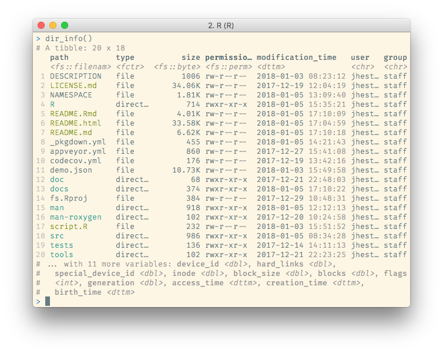

**fs** provides a cross-platform, uniform interface to file system operations. It shares the same back-end component as [nodejs](https://nodejs.org/), the [libuv](http://docs.libuv.org/en/v1.x/fs.html) C library, which brings the benefit of extensive real-world use and rigorous cross-platform testing. The name, and some of the interface, is partially inspired by Rust’s [fs module](https://doc.rust-lang.org/std/fs/index.html).

## Installation

You can install the released version of **fs** from [CRAN](https://cran.r-project.org/) with:

```r
install.packages("fs")
```

And the development version from [GitHub](https://github.com/) with:

```r
# install.packages("devtools")
devtools::install_github("r-lib/fs")
```

## Comparison vs base equivalents

**fs** functions smooth over some of the idiosyncrasies of file handling with base R functions:

- Vectorization. All **fs** functions are vectorized, accepting multiple paths as input. Base functions are inconsistently vectorized.
- Predictable return values that always convey a path. All **fs** functions return a character vector of paths, a named integer or a logical vector, where the names give the paths. Base return values are more varied: they are often logical or contain error codes which require downstream processing.
- Explicit failure. If **fs** operations fail, they throw an error. Base functions tend to generate a warning and a system dependent error code. This makes it easy to miss a failure.
- UTF-8 all the things. **fs** functions always convert input paths to UTF-8 and return results as UTF-8. This gives you path encoding consistency across OSes. Base functions rely on the native system encoding.
- Naming convention. **fs** functions use a consistent naming convention. Because base R’s functions were gradually added over time there are a number of different conventions used (e.g. `path.expand()` vs `normalizePath()`; `Sys.chmod()` vs `file.access()`).

### Tidy paths

**fs** functions always return ‘tidy’ paths. Tidy paths

- Always use `/` to delimit directories
- never have multiple `/` or trailing `/`

Tidy paths are also coloured (if your terminal supports it) based on the file permissions and file type. This colouring can be customised or extended by setting the `LS_COLORS` environment variable, in the same output format as [GNU dircolors](http://www.bigsoft.co.uk/blog/index.php/2008/04/11/configuring-ls_colors).

## Usage

**fs** functions are divided into four main categories:

- `path_` for manipulating paths
- `file_` for files
- `dir_` for directories
- `link_` for links

Directories and links are special types of files, so `file_` functions will generally also work when applied to a directory or link.

```r
library(fs)

# list files in the current directory
dir_ls()
```

```
#> DESCRIPTION      LICENSE.md       NAMESPACE        NEWS.md
#> R                README.Rmd       README.md        _pkgdown.yml
#> appveyor.yml     codecov.yml      cran-comments.md docs
#> fs.Rproj         inst             man              man-roxygen
#> src              tests            vignettes
```

```r
# create a new directory
tmp <- dir_create(file_temp())
tmp
```

```
#> /tmp/RtmpMLBzLW/file7c763d3ffc67
```

```r
# create new files in that directory
file_create(path(tmp, "my-file.txt"))
dir_ls(tmp)
```

```
#> /tmp/RtmpMLBzLW/file7c763d3ffc67/my-file.txt
```

```r
# remove files from the directory
file_delete(path(tmp, "my-file.txt"))
dir_ls(tmp)
```

```
#> character(0)
```

```r
# remove the directory
dir_delete(tmp)
```

**fs** is designed to work well with the pipe, though because it is a minimal-dependency infrastructure package it doesn’t provide the pipe itself. You will need to attach [magrittr](http://magrittr.tidyverse.org/) or similar.

```r
library(magrittr)

paths <- file_temp() %>%
  dir_create() %>%
  path(letters[1:5]) %>%
  file_create()
paths
```

```
#> /tmp/RtmpMLBzLW/file7c762a71251a/a /tmp/RtmpMLBzLW/file7c762a71251a/b
#> /tmp/RtmpMLBzLW/file7c762a71251a/c /tmp/RtmpMLBzLW/file7c762a71251a/d
#> /tmp/RtmpMLBzLW/file7c762a71251a/e
```

```r
paths %>% file_delete()
```

**fs** functions also work well in conjunction with other [tidyverse](https://www.tidyverse.org/) packages, like [dplyr](http://dplyr.tidyverse.org/) and [purrr](http://purrr.tidyverse.org/).

Some examples…

```r
suppressMessages(
  library(tidyverse))
```

Filter files by type, permission and size

```r
dir_info("src", recursive = FALSE) %>%
  filter(type == "file", permissions == "u+r", size > "10KB") %>%
  arrange(desc(size)) %>%
  select(path, permissions, size, modification_time)
```

```
#> # A tibble: 9 x 4
#>   path                permissions        size modification_time
#>   <fs::path>          <fs::perms> <fs::bytes> <dttm>
#> 1 src/RcppExports.o   rw-rw-r--         1.72M 2018-03-05 09:13:43
#> 2 src/dir.o           rw-rw-r--         1.02M 2018-03-05 09:13:37
#> 3 src/id.o            rw-rw-r--       707.09K 2018-03-05 09:13:23
#> 4 src/file.o          rw-rw-r--       573.33K 2018-03-05 09:13:25
#> 5 src/path.o          rw-rw-r--       476.63K 2018-03-05 09:13:31
#> 6 src/link.o          rw-rw-r--        415.2K 2018-03-05 09:13:28
#> 7 src/utils.o         rw-rw-r--       392.21K 2018-03-05 09:13:33
#> 8 src/error.o         rw-rw-r--        35.45K 2018-03-05 09:13:37
#> 9 src/RcppExports.cpp rw-rw-r--        11.01K 2018-03-05 09:08:25
```

Tabulate and display folder size.

```r
dir_info("src", recursive = TRUE) %>%
  group_by(directory = path_dir(path)) %>%
  tally(wt = size, sort = TRUE)
```

```
#> # A tibble: 53 x 2
#>    directory                                        n
#>    <fs::path>                             <fs::bytes>
#>  1 src                                          5.33M
#>  2 src/libuv                                    2.47M
#>  3 src/libuv/test                             869.22K
#>  4 src/libuv/src/win                          683.14K
#>  5 src/libuv/src/unix                         518.71K
#>  6 src/unix                                   429.67K
#>  7 src/libuv/docs/src/static                  332.05K
#>  8 src/libuv/m4                               319.95K
#>  9 src/libuv/include                          192.33K
#> 10 src/libuv/docs/src/static/diagrams.key     191.74K
#> # ... with 43 more rows
```

Read a collection of files into one data frame.

`dir_ls()` returns a named vector, so it can be used directly with `purrr::map_df(.id)`.

```r
# Create separate files for each species
iris %>%
  split(.$Species) %>%
  map(select, -Species) %>%
  iwalk(~ write_tsv(.x, paste0(.y, ".tsv")))

# Show the files
iris_files <- dir_ls(glob = "*.tsv")
iris_files
```

```
#> setosa.tsv     versicolor.tsv virginica.tsv
```

```r
# Read the data into a single table, including the filenames
iris_files %>%
  map_df(read_tsv, .id = "file", col_types = cols(), n_max = 2)
```

```
#> # A tibble: 6 x 5
#>   file           Sepal.Length Sepal.Width Petal.Length Petal.Width
#>   <chr>                 <dbl>       <dbl>        <dbl>       <dbl>
#> 1 setosa.tsv             5.10        3.50         1.40       0.200
#> 2 setosa.tsv             4.90        3.00         1.40       0.200
#> 3 versicolor.tsv         7.00        3.20         4.70       1.40
#> 4 versicolor.tsv         6.40        3.20         4.50       1.50
#> 5 virginica.tsv          6.30        3.30         6.00       2.50
#> 6 virginica.tsv          5.80        2.70         5.10       1.90
```

```r
file_delete(iris_files)
```

## Feedback wanted!

We hope **fs** is a useful tool for both analysis scripts and packages. Please open [GitHub issues](https://github.com/r-lib/fs) for any feature requests or bugs.

In particular, we have found non-ASCII filenames in non-English locales on Windows to be especially tricky to reproduce and handle correctly. Feedback from users who use commonly have this situation is greatly appreciated.